# Homework 5

Laura Brubaker-Wittman

11/6/2019

# Bootstrapping Standard Errors and CIs for Linear Models

**Directions:**

*When we initially discussed the central limit theorem and confidence intervals, we showed how we could use bootstrapping to estimate standard errors and confidence intervals around certain parameter values, like the mean. Using bootstrapping, we could also do the same for estimating standard errors and CIs around regression parameters, such as β coefficients.*

**Question #1:**

*Using the “KamilarAndCooperData.csv” dataset, run a linear regression looking at log(HomeRange_km2) in relation to log(Body_mass_female_mean) and report your β coeffiecients (slope and intercept).*

First, I will call up the Kamilar and Cooper dataset:

```r
library(curl)
f <- curl("https://raw.githubusercontent.com/fuzzyatelin/fuzzyatelin.github.io/master/AN597_Fall19/KamilarAndCooperData.csv")
d <- read.csv(f, header = TRUE, sep = ",", stringsAsFactors = FALSE)
head(d)
```

```
##               Scientific_Name          Family          Genus      Species
## 1 Allenopithecus_nigroviridis Cercopithecidae Allenopithecus nigroviridis
## 2         Allocebus_trichotis Cercopithecidae      Allocebus    trichotis
## 3           Alouatta_belzebul        Atelidae       Alouatta     belzebul
## 4             Alouatta_caraya        Atelidae       Alouatta       caraya
## 5            Alouatta_guariba        Atelidae       Alouatta      guariba
## 6           Alouatta_palliata        Atelidae       Alouatta     palliata
##   Brain_Size_Species_Mean Brain_Size_Female_Mean   Brain_size_Ref
## 1                   58.02                  53.70 Isler et al 2008
## 2                      NA                     NA
## 3                   52.84                  51.19 Isler et al 2008
## 4                   52.63                  47.80 Isler et al 2008
## 5                   51.70                  49.08 Isler et al 2008
## 6                   49.88                  48.04 Isler et al 2008
##   Body_mass_male_mean Body_mass_female_mean Mass_Dimorphism
```

[output cut: 69 more lines]

Looks good! Now we can use our lm() function to see if we can get at the answers we are looking for:

```r
d$loghr <- log(d$HomeRange_km2) # assigning the log of home range to loghr
d$logbm <- log(d$Body_mass_female_mean) # assigning mean female body mass to logbm
log_model <- lm(data = d, loghr ~ logbm)
log_model
```

```
##
## Call:
## lm(formula = loghr ~ logbm, data = d)
##
## Coefficients:
## (Intercept)        logbm
##      -9.441        1.036
```

So, this is telling us our β coefficients are -9.441 for our β<sub>0</sub> or **intercept** and 1.036 for our β<sub>1</sub> or **slope**.

I believe this is all that Question #1 is asking for, so we will move on to Question #2!

**Question #2:**

*Then, use bootstrapping to sample from your data 1000 times with replacement, each time fitting the same model and calculating the same coefficients. This generates a sampling distribution for each β coefficient.*

1. *Estimate the standard error for each of your β coefficients as the standard deviation of the sampling distribution from your bootstrap and determine the 95% CI for each of your β coefficients based on the appropriate quantiles from your sampling distribution.*
2. *How does the former compare to the SE estimated from your entire dataset using the formula for standard error implemented in lm()?*
3. *How does the latter compare to the 95% CI estimated from your entire dataset?*

So, after much looking around on the internet, here is the code I came up with (thanks Google!):

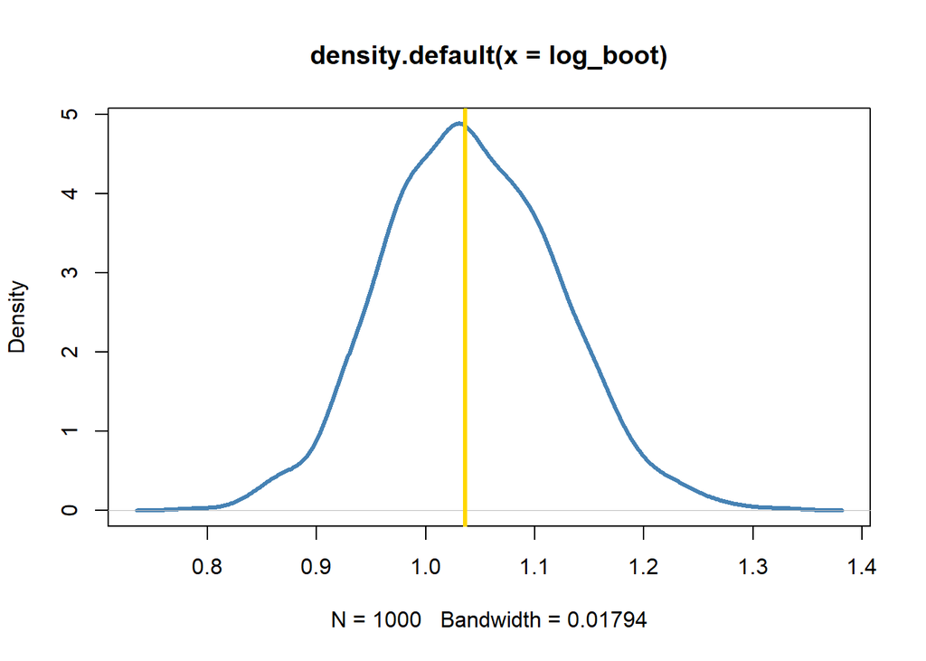

```r
log_boot <- numeric(1000)
for (i in 1:1000) {
  this.ind <- sample(213, 213, replace = TRUE)
  log_boot[i] <- coef(lm
                      (d$loghr[this.ind] ~ d$logbm[this.ind])) [2]
  }
plot(density(log_boot), lwd = 3, col = "steelblue")
abline(v = coef(lm(d$loghr ~ d$logbm)) [2], lwd = 3, col = "gold")
```

I used 213 as that was the size of the original number of observations, though I think there could be arguments for why you could use a different number. I honestly am not sure if this is exactly what we are looking for, but I do think it is interesting that it gave back a something kind of resembling a normal distribution?

For the confidence intervals, I used a function, quantile(), that we learned in Module 7, and just used amounts that would set us up for a 95% confidence interval

```r
quantile(log_boot, c(0.025, 0.975))
```

```
##      2.5%     97.5%
## 0.8858086 1.2009492
```

And here is for standard error, though I am worried this is too straightforward? Am I missing something?

```r
library(sciplot)
se(log_boot)
```

```
## [1] 0.002510155
```

It also asks us to compare this standard error to the one we found in Question 1, using the lm() function. Let’s pull this out now:

```r
summary(log_model)
```

```
##
## Call:
## lm(formula = loghr ~ logbm, data = d)
##
## Residuals:
##     Min      1Q  Median      3Q     Max
## -3.3929 -0.9433 -0.0126  1.0944  3.6826
##
## Coefficients:
##             Estimate Std. Error t value Pr(>|t|)
## (Intercept) -9.44123    0.67293  -14.03   <2e-16 ***
## logbm        1.03643    0.08488   12.21   <2e-16 ***
## ---
## Signif. codes:  0 '***' 0.001 '**' 0.01 '*' 0.05 '.' 0.1 ' ' 1
##
## Residual standard error: 1.423 on 135 degrees of freedom
##   (76 observations deleted due to missingness)
## Multiple R-squared:  0.5248, Adjusted R-squared:  0.5213
## F-statistic: 149.1 on 1 and 135 DF,  p-value: < 2.2e-16
```

## Challenges:

1. Not sure if I am doing a bootstrap process correctly for a linear regression. I looked up a lot of information on this, and there seemed to be multiple solutions for how to do this, though for many I was lost on what to put for certain parts of the function.
2. Not sure if my standard errors are correct. This also means I am just not familar enough with standard error to know if these numbers make sense or not.
3. Did not even try the extra credit. I feel pretty lost as far as writing functions. I think I need to find some online tutorials and examples to continue to go through that until I feel more comfortable with it.
4. Not really a challenge, but I was so interested in how many packages were suggested for doing bootstrapping when I did some internet research! The number of packages available is just overwhelming, and while that is exciting to know there are multiple ways to find answers to research questions, it is also a bit daunting to know if you are doing it the way that is best for your data or is the most efficient. I guess that is part of the learning process!